# 11 ggplot

## 11.1 Deconstructing a graph

### 11.1.1 The Grammar of Graphics (`gg`)

Yau (2013) and Wickham (2014) have come up with a *taxonomy* and a *grammar* for thinking about the parts of a figure just like we conceptualize the parts of a body or the parts of a sentence.

One great way of thinking of the new process: it is no longer necessary to talk about the name of the graph (e.g., boxplot). Instead we now think in glyphs (geoms), and so we can put whatever we want on the plot. Note also that the transition leads you from a passive consumer (I need to make plot XXX because everyone else does, so I just plug in the data) into an active participant (what do I want my data to say? and how can I put that information onto my graphic?)

The most important questions you can ask with respect to creating figures are:

1. What do we want R to do? (What is the goal?)
2. What does R need to know?

Yau (2013) gives us nine visual cues, and Wickham (2014) translates them into a language using `ggplot2`. (The items below are from Baumer et al. (2021), chapter 2.)

1. Visual Cues: the aspects of the figure where we should focus.  
   **Position** (numerical) where in relation to other things?  
   **Length** (numerical) how big (in one dimension)?  
   **Angle** (numerical) how wide? parallel to something else?  
   **Direction** (numerical) at what slope? In a time series, going up or down?  
   **Shape** (categorical) belonging to what group?  
   **Area** (numerical) how big (in two dimensions)? Beware of improper scaling!  
   **Volume** (numerical) how big (in three dimensions)? Beware of improper scaling!  
   **Shade** (either) to what extent? how severely?  
   **Color** (either) to what extent? how severely? Beware of red/green color blindness. Use color-vision-safe palettes like [`viridis`](https://ggplot2.tidyverse.org/reference/scale_viridis.html) or [`Okabe–Ito`](https://malcolmbarrett.github.io/ggokabeito/).
2. Coordinate System: rectangular, polar, geographic, etc.
3. Scale: numeric (linear? logarithmic?), categorical (ordered?), time
4. Context: in comparison to what (think back to ideas from Tufte)

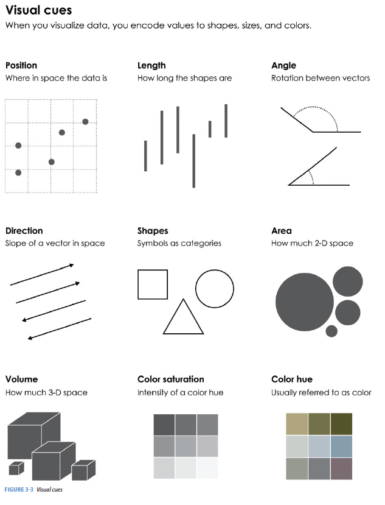

Figure 3.3 of Yau’s *Data Points: Visualization That Means Something*, https://flowingdata.com/data-points/DataPoints-Ch3.pdf, (Yau 2013).

#### Order Matters

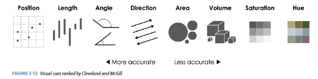

Figure 3.12 of Yau’s *Data Points: Visualization That Means Something*, https://flowingdata.com/data-points/DataPoints-Ch3.pdf, (Yau 2013). Original work by Cleveland and McGill (1984).

#### Cues Together

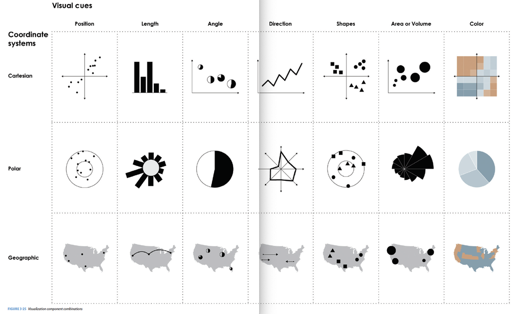

Figure 3.25 of Yau’s *Data Points: Visualization That Means Something*, https://flowingdata.com/data-points/DataPoints-Ch3.pdf, (Yau 2013).

##### What are the visual cues on the plot?

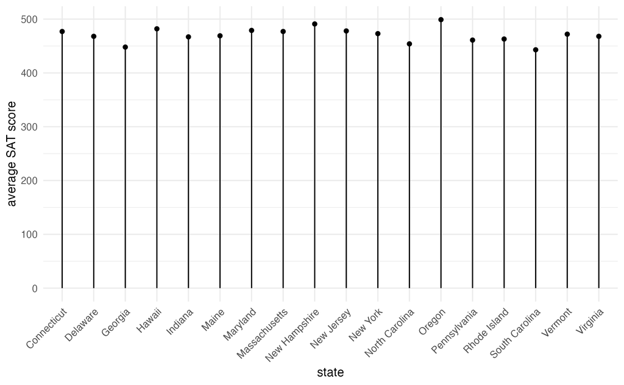

- position?
- length?
- shape?
- area/volume?
- shade/color?
- coordinate System?
- scale?

##### What are the visual cues on the plot?

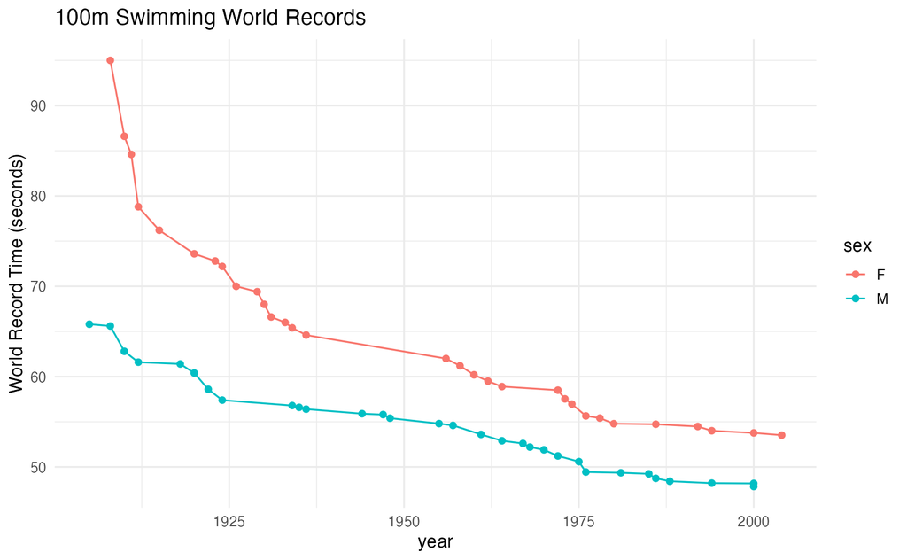

- position?
- length?
- shape?
- area/volume?
- shade/color?
- coordinate System?
- scale?

##### What are the visual cues on the plot?

[figure not shown]

- position?
- length?
- shape?
- area/volume?
- shade/color?
- coordinate System?
- scale?

#### 11.1.1.1 The grammar of graphics in `ggplot2`

**geom**: the geometric “shape” used to display data

- bar, point, line, ribbon, text, etc.

**aesthetic**: an attribute controlling how geom is displayed with respect to variables

- x position, y position, color, fill, shape, size, etc.

**scale**: adjust information in the aesthetic to map onto the plot

- *particular* assignment of colors, shapes, sizes, etc.; making axes continuous or constrained to a particular range of values.

**guide**: helps user convert visual data back into raw data (legends, axes)

**stat**: a transformation applied to data before geom gets it

- example: histograms work on binned data

### 11.1.2 `ggplot2`

In `ggplot2`, an *aesthetic* refers to a mapping between a variable and the information it conveys on the plot. Further information about plotting and visualizing information is given in chapter 2 (Data visualization) of Baumer et al. (2021). Much of the data in the presentation represents all births from 1978 in the US: the date, the day of the year, and the number of births.

##### Goals

What I will try to do

- give a tour of `ggplot2`
- explain how to think about plots the `ggplot2` way
- prepare/encourage you to learn more later

What I can’t do in one session

- show every bell and whistle
- make you an expert at using `ggplot2`

##### Getting help

1. One of the best ways to get started with ggplot is to Google what you want to do with the word ggplot. Then look through the images that come up. More often than not, the associated code is there. There are also ggplot galleries of images, one of them is here: https://plot.ly/ggplot2/
2. `ggplot2` cheat sheet: https://opensource.posit.co/resources/cheatsheets/data-visualization/
3. Look at the end of the presentation. More help options there.

[figure not shown]

```r
require(mosaic) # where Births78 lives
data(Births78) # restore fresh version of Births78
```

```r
head(Births78, 3)
```

| date | births | wday | year | month | day_of_year | day_of_month | day_of_week |
| --- | --- | --- | --- | --- | --- | --- | --- |
| 1978-01-01 | 7701 | Sun | 1978 | 1 | 1 | 1 | 1 |
| 1978-01-02 | 7527 | Mon | 1978 | 1 | 2 | 2 | 2 |
| 1978-01-03 | 8825 | Tue | 1978 | 1 | 3 | 3 | 3 |

##### How can we make the plot?

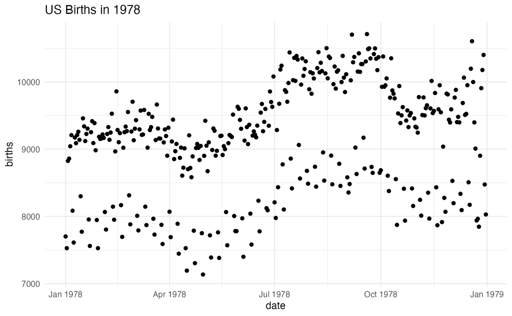

Two Questions:

1. What do we want R to do? (What is the goal?)
2. What does R need to know?
   - data source: `Births78`
   - aesthetics:
     - `date -> x`
     - `births -> y`
     - points (!)
3. Goal: scatterplot = a plot with points
   - `ggplot() + geom_point()`
4. What does R need to know?
   - data source: `data = Births78`
   - aesthetics: `aes(x = date, y = births)`

##### How can we make the plot?

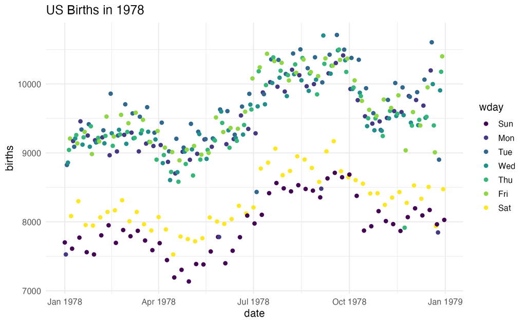

What has changed?

- new aesthetic: mapping color to day of week

##### Adding day of week to the data set

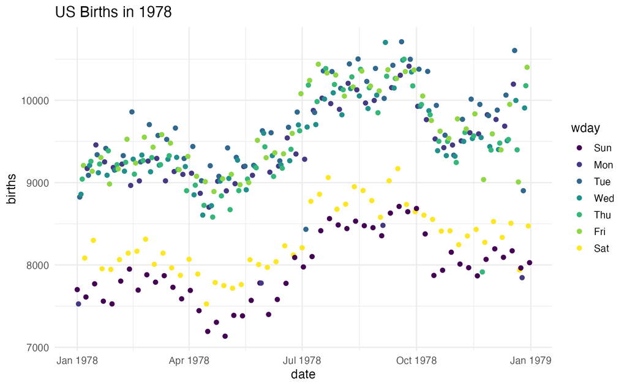

```r
ggplot(data = Births78) +
  geom_point(aes(x = date, y = births, color = wday)) +
  labs(title = "US Births in 1978")
```

##### How can we make the plot?

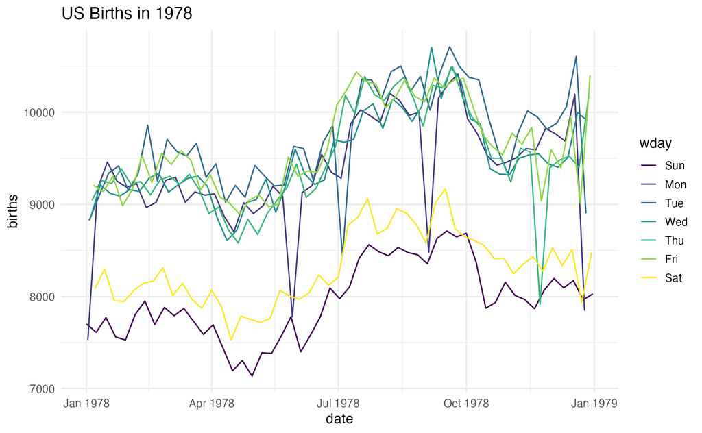

Now we use lines instead of dots

```r
ggplot(data = Births78) +
  geom_line(aes(x = date, y = births, color = wday)) +
  labs(title = "US Births in 1978")
```

##### How can we make the plot?

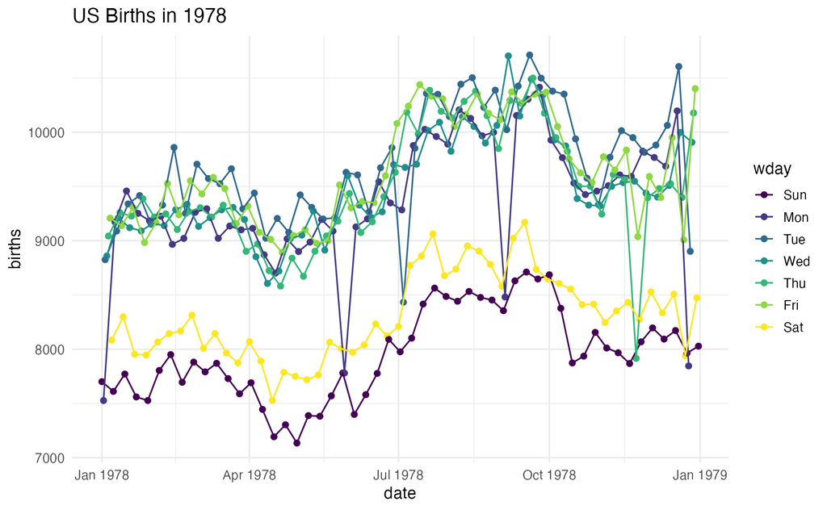

Now we have two **layers**, one with points and one with lines

```r
ggplot(data = Births78, aes(x = date, y = births, color = wday)) +
  geom_point() +
  geom_line() +
  labs(title = "US Births in 1978")
```

- The layers are placed one on top of the other: the points are *below* and the lines are *above*.
- `data` and `aes` specified in `ggplot()` affect all geoms

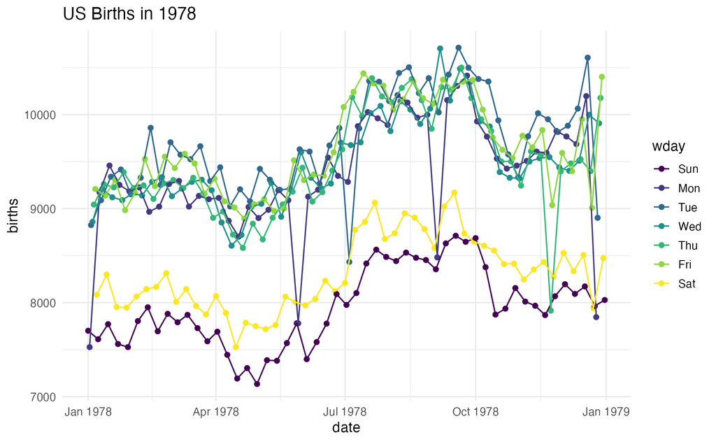

```r
ggplot(data = Births78, aes(x = date, y = births, color = wday)) +
  geom_point() +
  geom_line() +
  labs(title = "US Births in 1978")
```

##### What does adding the color argument do?

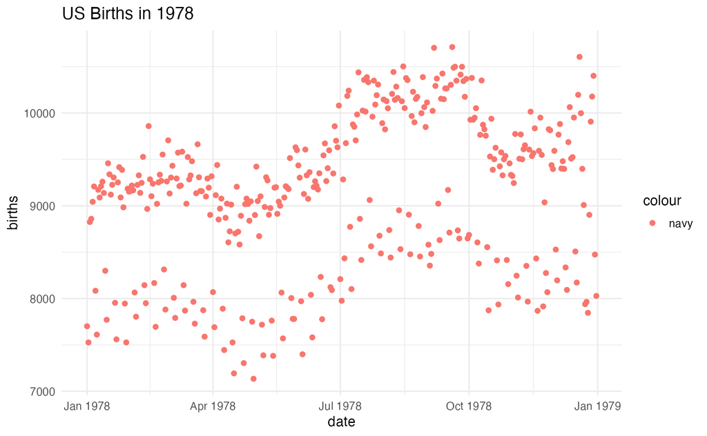

```r
ggplot(data = Births78, aes(x = date, y = births, color = "navy")) +
  geom_point() +
  labs(title = "US Births in 1978")
```

Because there is no variable, we have *mapped* the color aesthetic to a new variable with only one value (“navy”). So all the dots get set to the same color, but it’s not navy.

##### Setting vs. Mapping

If we want to *set* the color to be navy for all of the dots, we do it outside the aesthetic, without a dataset variable:

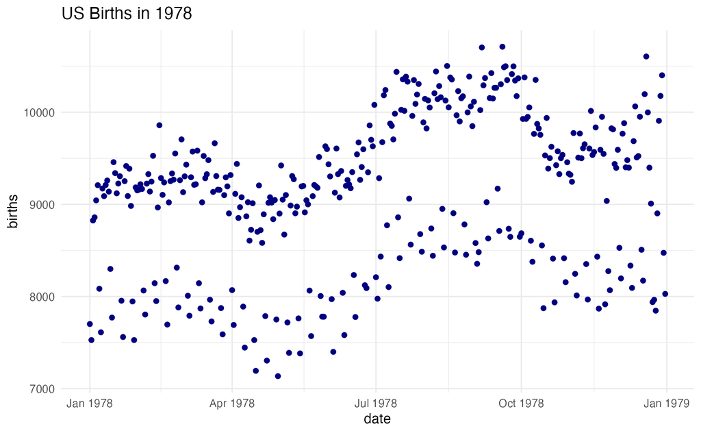

```r
ggplot(data = Births78, aes(x = date, y = births)) + # map x & y
  geom_point(color = "navy") + # set color
  labs(title = "US Births in 1978")
```

- Note that `color = "navy"` is now outside of the aesthetics list. That’s how `ggplot2` distinguishes between mapping and setting.

##### How can we make the plot?

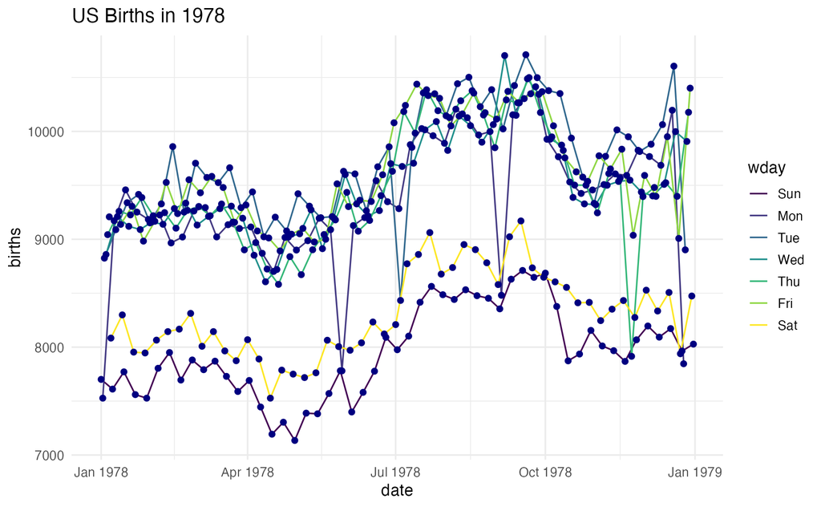

```r
ggplot(data = Births78, aes(x = date, y = births)) +
  geom_line(aes(color = wday)) + # map color here
  geom_point(color = "navy") + # set color here
  labs(title = "US Births in 1978")
```

- `ggplot()` establishes the default data and aesthetics for the geoms, but each geom may change the defaults.
- good practice: put into `ggplot()` the things that affect all (or most) of the layers; rest in `geom_blah()`

##### Setting vs. Mapping (again)

Information gets passed to the plot via:

1. `map` the **variable** information inside the aes (aesthetic) command
2. `set` the **non-variable** information outside the aes (aesthetic) command

##### Other geoms

```r
apropos("^geom_")
```

```
 [1] "geom_abline"                  "geom_area"
 [3] "geom_ash"                     "geom_bar"
 [5] "geom_bin_2d"                  "geom_bin2d"
 [7] "geom_blank"                   "geom_boxplot"
 [9] "geom_bracket"                 "geom_col"
[11] "geom_contour"                 "geom_contour_filled"
[13] "geom_count"                   "geom_crossbar"
[15] "geom_curve"                   "geom_density"
[17] "geom_density_2d"              "geom_density_2d_filled"
[19] "geom_density_line"            "geom_density_ridges"
[21] "geom_density_ridges_gradient" "geom_density_ridges2"
[23] "geom_density2d"               "geom_density2d_filled"
[25] "geom_dotplot"                 "geom_errorbar"
[27] "geom_errorbarh"               "geom_exec"
[29] "geom_freqpoly"                "geom_function"
```

[output cut: 21 more lines]

help pages will tell you their aesthetics, default stats, etc.

```r
?geom_area # for example
```

##### Let’s try `geom_area`

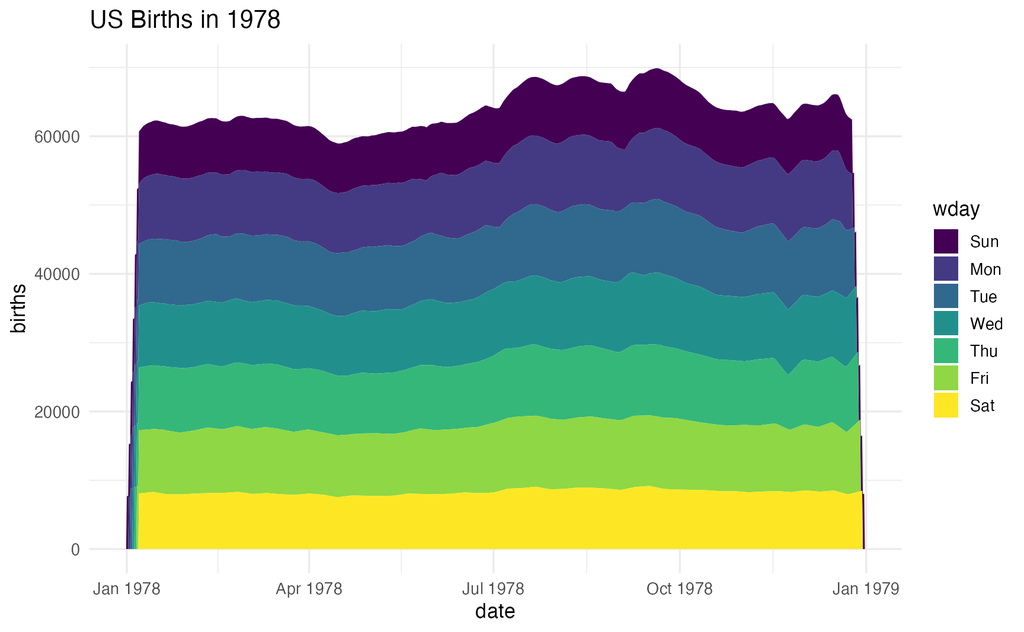

```r
ggplot(data = Births78, aes(x = date, y = births, fill = wday)) +
  geom_area() +
  labs(title = "US Births in 1978")
```

Using area does not produce a good plot

- over plotting is hiding much of the data
- extending y-axis to 0 may or may not be desirable.

##### Side note: what makes a plot good?

Most (all?) graphics are intended to help us make comparisons

- How does something change over time?
- Do my treatments matter? How much?
- Do men and women respond the same way?

**Key plot metric:** Does my plot make the comparisons I am interested in

- easily, and
- accurately?

##### Time for some different data

`HELPrct`: Health Evaluation and Linkage to Primary care randomized clinical trial

```r
head(HELPrct)
```

| age | anysubstatus | anysub | cesd | d1 | daysanysub | dayslink | drugrisk | e2b | female | sex | g1b | homeless | i1 | i2 | id | indtot | linkstatus | link | mcs | pcs | pss_fr | racegrp | satreat | sexrisk | substance | treat | avg_drinks | max_drinks | hospitalizations |
| --- | --- | --- | --- | --- | --- | --- | --- | --- | --- | --- | --- | --- | --- | --- | --- | --- | --- | --- | --- | --- | --- | --- | --- | --- | --- | --- | --- | --- | --- |
| 37 | 1 | yes | 49 | 3 | 177 | 225 | 0 | NA | 0 | male | yes | housed | 13 | 26 | 1 | 39 | 1 | yes | 25.11 | 58.4 | 0 | black | no | 4 | cocaine | yes | 13 | 26 | 3 |
| 37 | 1 | yes | 30 | 22 | 2 | NA | 0 | NA | 0 | male | yes | homeless | 56 | 62 | 2 | 43 | NA | NA | 26.67 | 36.0 | 1 | white | no | 7 | alcohol | yes | 56 | 62 | 22 |
| 26 | 1 | yes | 39 | 0 | 3 | 365 | 20 | NA | 0 | male | no | housed | 0 | 0 | 3 | 41 | 0 | no | 6.76 | 74.8 | 13 | black | no | 2 | heroin | no | 0 | 0 | 0 |
| 39 | 1 | yes | 15 | 2 | 189 | 343 | 0 | 1 | 1 | female | no | housed | 5 | 5 | 4 | 28 | 0 | no | 43.97 | 61.9 | 11 | white | yes | 4 | heroin | no | 5 | 5 | 2 |
| 32 | 1 | yes | 39 | 12 | 2 | 57 | 0 | 1 | 0 | male | no | homeless | 10 | 13 | 5 | 38 | 1 | yes | 21.68 | 37.3 | 10 | black | no | 6 | cocaine | no | 10 | 13 | 12 |
| 47 | 1 | yes | 6 | 1 | 31 | 365 | 0 | NA | 1 | female | no | housed | 4 | 4 | 6 | 29 | 0 | no | 55.51 | 46.5 | 5 | black | no | 5 | cocaine | yes | 4 | 4 | 1 |

Subjects admitted for treatment for addiction to one of three substances.

##### Who are the people in the study?

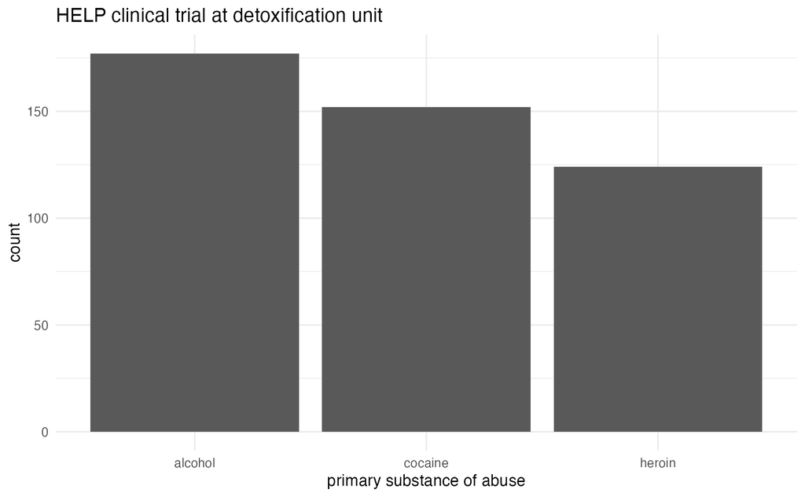

```r
ggplot(data = HELPrct, aes(x = substance)) +
  geom_bar() +
  labs(title = "HELP clinical trial at detoxification unit")
```

- Hmm. What’s up with `y`?
  - `stat_bin()` is being applied to the data before the `geom_bar()` gets to do its thing. Binning creates the `y` values.

##### Who are the people in the study?

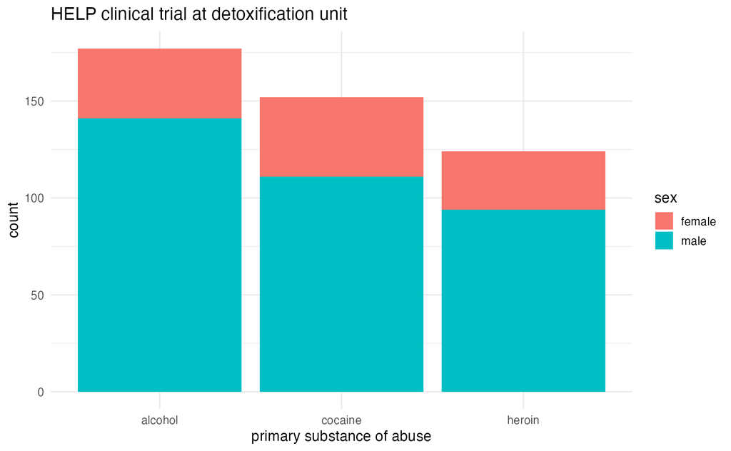

```r
ggplot(data = HELPrct, aes(x = substance, fill = sex)) +
  geom_bar() +
  labs(title = "HELP clinical trial at detoxification unit")
```

##### Who are the people in the study?

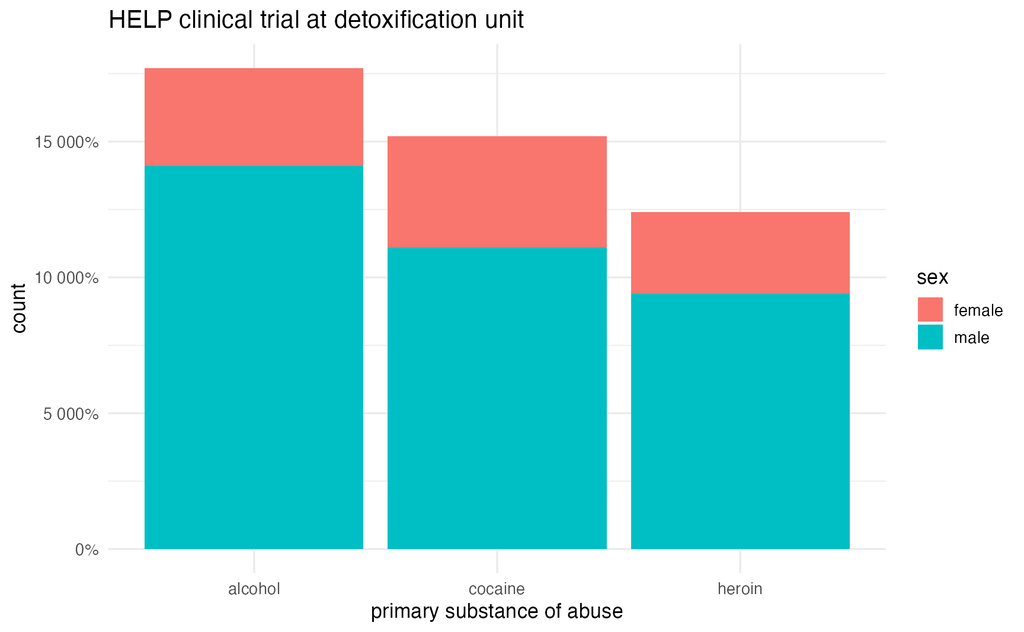

```r
library(scales)
ggplot(data = HELPrct, aes(x = substance, fill = sex)) +
  geom_bar() +
  scale_y_continuous(labels = percent) +
  labs(title = "HELP clinical trial at detoxification unit")
```

##### Who are the people in the study?

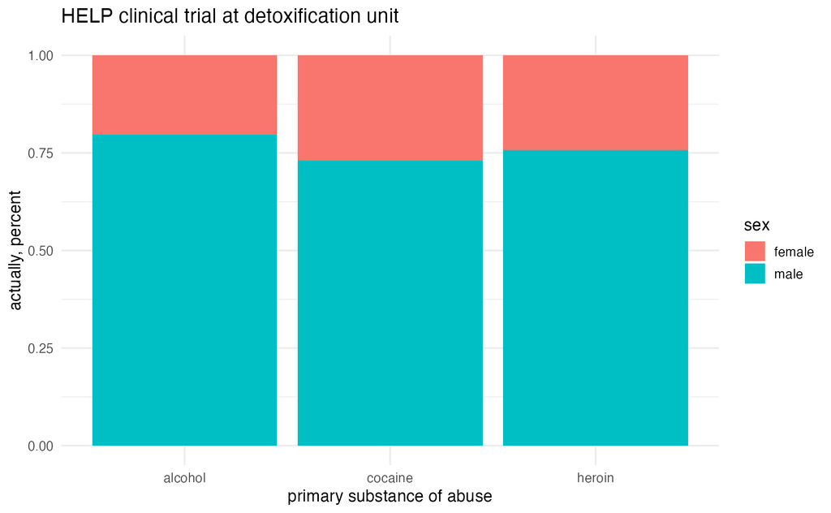

```r
ggplot(data = HELPrct, aes(x = substance, fill = sex)) +
  geom_bar(position = "fill") +
  scale_y_continuous("actually, percent") +
  labs(title = "HELP clinical trial at detoxification unit")
```

##### How old are people in the HELP study?

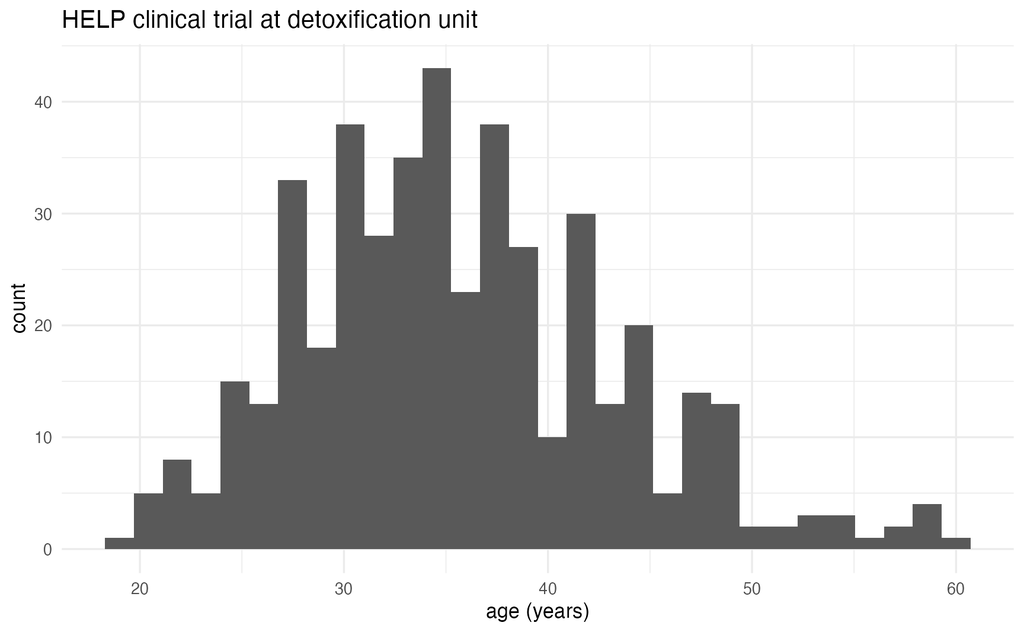

```r
ggplot(data = HELPrct, aes(x = age)) +
  geom_histogram() +
  labs(title = "HELP clinical trial at detoxification unit")
```

- `stat_bin`: Histograms are not mapping the raw data but binned data.  
  `stat_bin()` performs the data transformation.
- `binwidth`: a default `binwidth` has been selected, but we should really choose our own.

##### Setting the binwidth manually

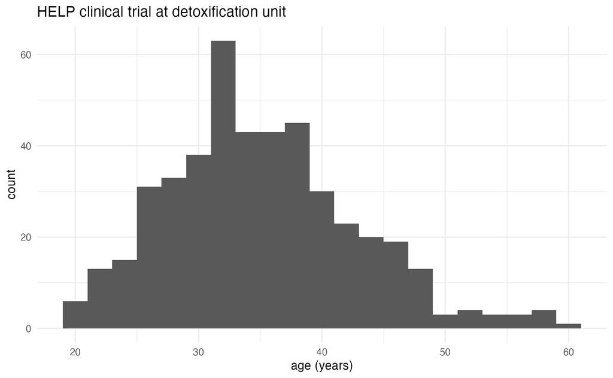

```r
ggplot(data = HELPrct, aes(x = age)) +
  geom_histogram(binwidth = 2) +
  labs(title = "HELP clinical trial at detoxification unit")
```

##### How old are people in the HELP study? – Other geoms

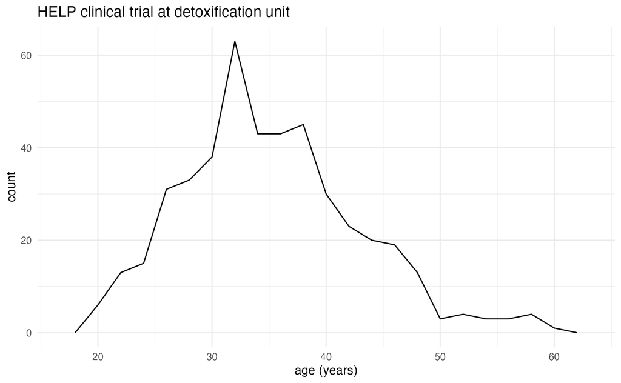

```r
ggplot(data = HELPrct, aes(x = age)) +
  geom_freqpoly(binwidth = 2) +
  labs(title = "HELP clinical trial at detoxification unit")
```

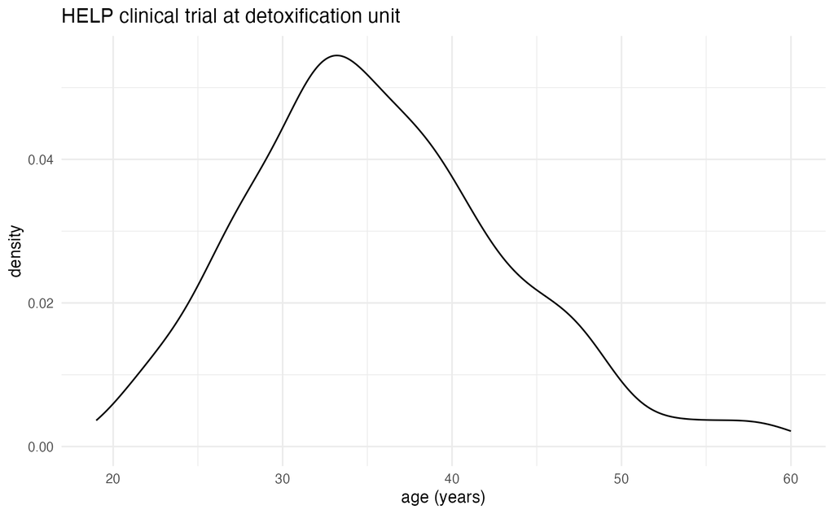

```r
ggplot(data = HELPrct, aes(x = age)) +
  geom_density() +
  labs(title = "HELP clinical trial at detoxification unit")
```

##### Selecting stat and geom manually

Every geom comes with a default stat

- for simple cases, the stat is `stat_identity()` which does nothing
- we can mix and match geoms and stats however we like

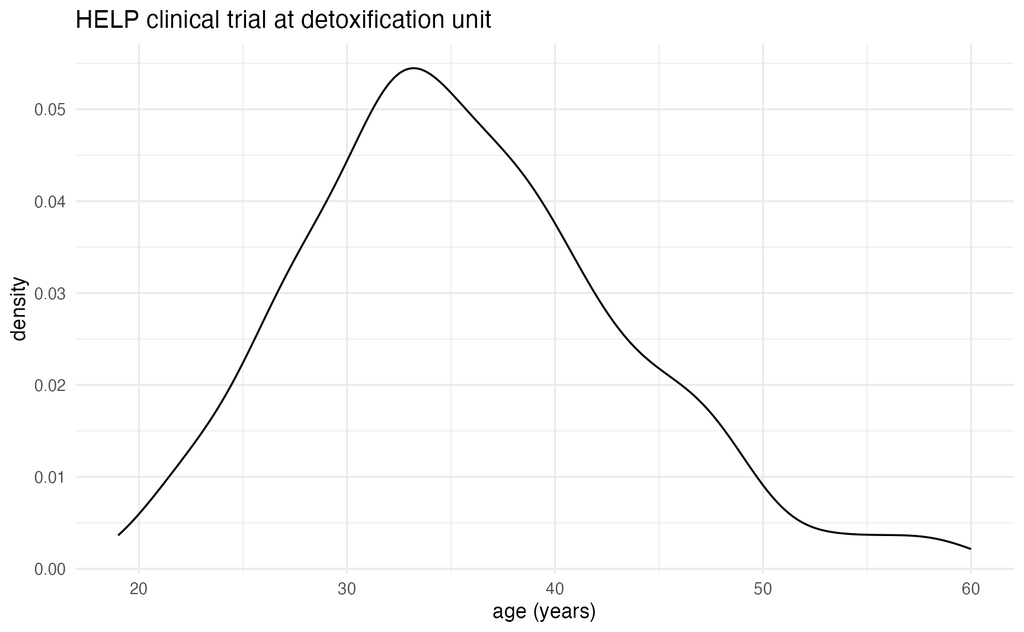

```r
ggplot(data = HELPrct, aes(x = age)) +
  geom_line(stat = "density") +
  labs(title = "HELP clinical trial at detoxification unit")
```

##### Selecting stat and geom manually

Every stat comes with a default `geom`, every geom with a default stat

- we can specify stats instead of `geom`, if we prefer
- we can mix and match geoms and stats however we like

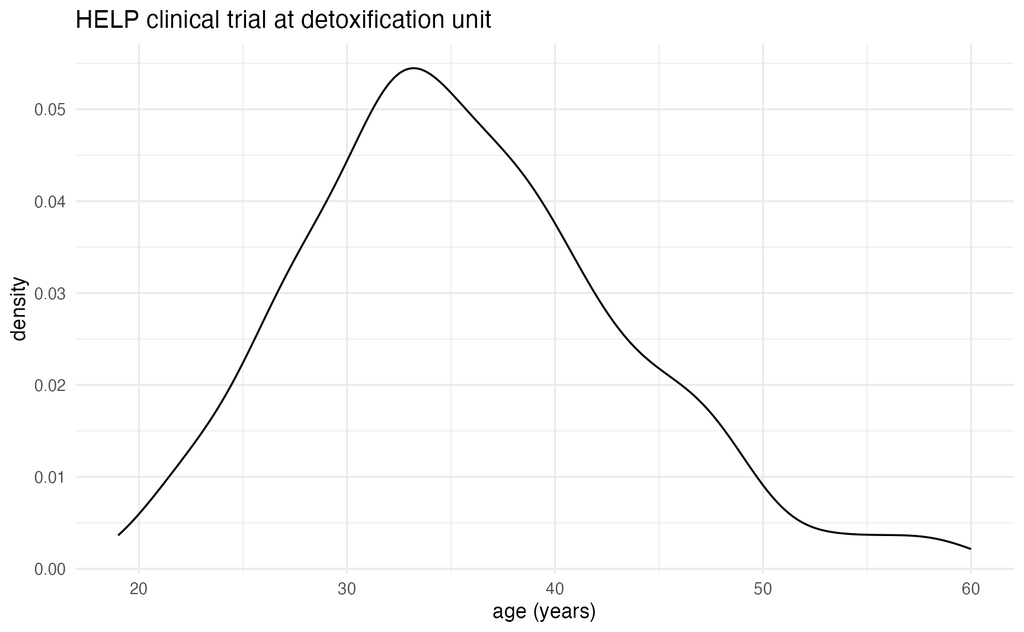

```r
ggplot(data = HELPrct, aes(x = age)) +
  stat_density(geom = "line") +
  labs(title = "HELP clinical trial at detoxification unit")
```

##### More combinations

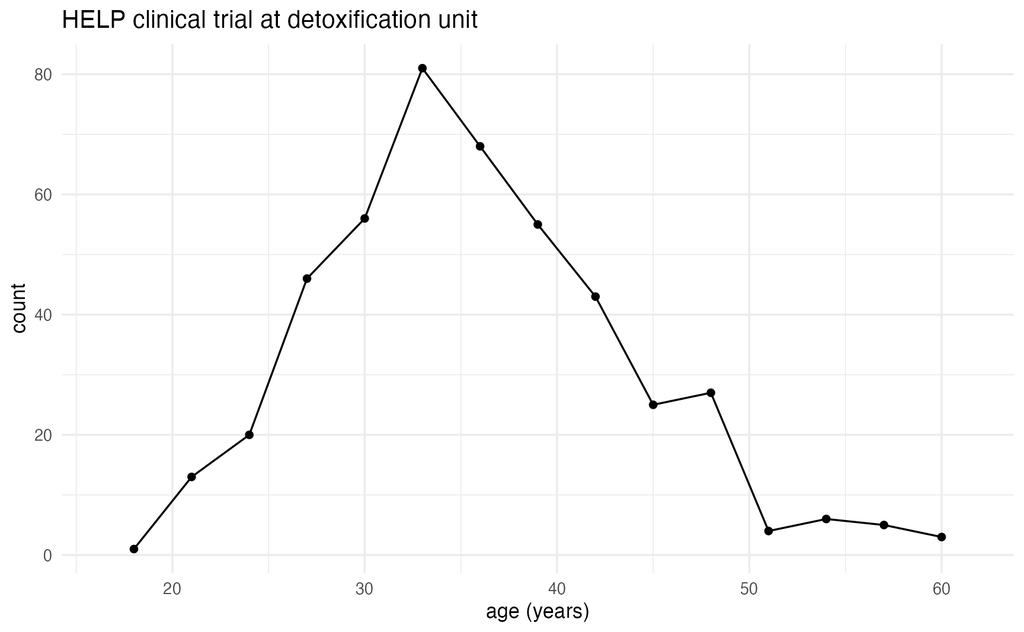

```r
ggplot(data = HELPrct, aes(x = age)) +
  geom_point(stat = "bin", binwidth = 3) +
  geom_line(stat = "bin", binwidth = 3) +
  labs(title = "HELP clinical trial at detoxification unit")
```

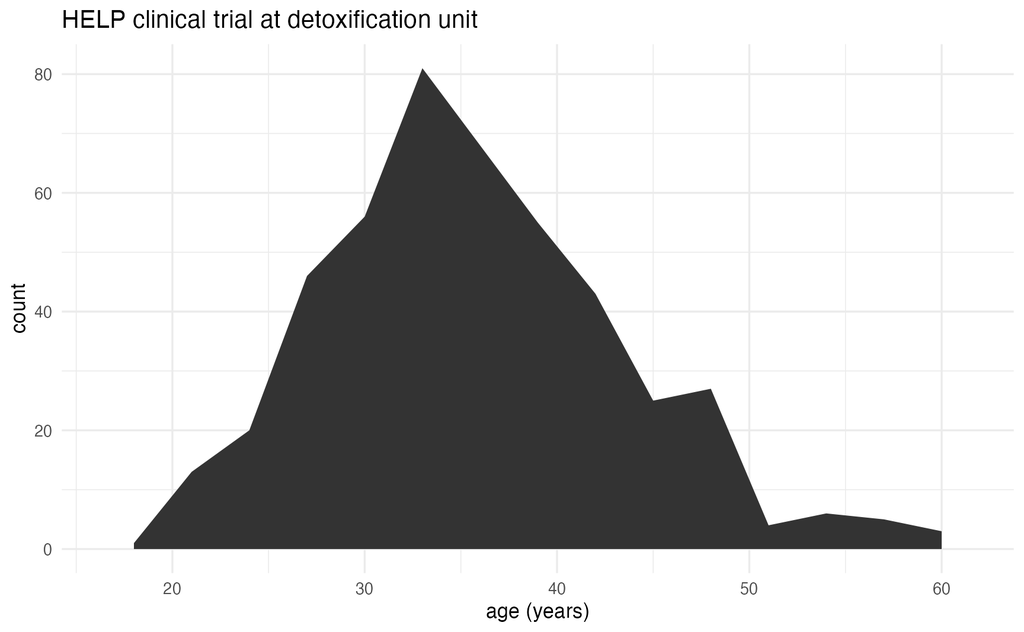

```r
ggplot(data = HELPrct, aes(x = age)) +
  geom_area(stat = "bin", binwidth = 3) +
  labs(title = "HELP clinical trial at detoxification unit")
```

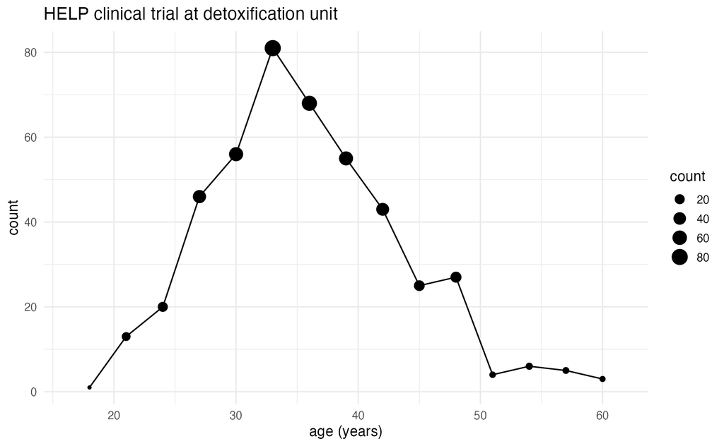

```r
ggplot(data = HELPrct, aes(x = age)) +
  geom_point(stat = "bin", binwidth = 3, aes(size = ..count..)) +
  geom_line(stat = "bin", binwidth = 3) +
  labs(title = "HELP clinical trial at detoxification unit")
```